# Visualización con Python, Numpy y pandas (cont.)

### 2.C. Pandas_profiling

[`pandas_profiling`](https://github.com/JosPolfliet/pandas-profiling) es, básicamente, la versión mejorada y visual de `mi_df.describe()`. Instalamos:

```
$ pip install pandas_profiling
```

Y utilizamos:

Overview

Dataset info

| Number of variables | 4 |
| --- | --- |
| Number of observations | 300 |
| Total Missing (%) | 39.8% |
| Total size in memory | 9.5 KiB |
| Average record size in memory | 32.3 B |

Variables types

| Numeric | 3 |
| --- | --- |
| Categorical | 1 |
| Date | 0 |
| Text (Unique) | 0 |
| Rejected | 0 |

Warnings

- `edad` has 128 / 42.7% missing values Missing

- `padre` has 108 / 36.0% missing values Missing

- `renta` has 121 / 40.3% missing values Missing

- `tiempo trabajando` has 120 / 40.0% missing values Missing

- `tiempo trabajando` has 12 / 4.0% zeros

- Dataset has 30 duplicate rows Warning

Variables

edad  
Numeric

| Distinct count | 173 |
| --- | --- |
| Unique (%) | 100.6% |
| Missing (%) | 42.7% |
| Missing (n) | 128 |
| Infinite (%) | 0.0% |
| Infinite (n) | 0 |

| Mean | 29.984 |
| --- | --- |
| Minimum | 18.707 |
| Maximum | 43.753 |
| Zeros (%) | 0.0% |

Toggle details

**Statistics**

Quantile statistics

| Minimum | 18.707 |
| --- | --- |
| 5-th percentile | 21.923 |
| Q1 | 26.717 |
| Median | 29.849 |
| Q3 | 33.452 |
| 95-th percentile | 38.352 |
| Maximum | 43.753 |
| Range | 25.047 |
| Interquartile range | 6.7354 |

Descriptive statistics

| Standard deviation | 4.9899 |
| --- | --- |
| Coef of variation | 0.16642 |
| Kurtosis | -0.18339 |
| Mean | 29.984 |
| MAD | 3.9103 |
| Skewness | 0.11889 |
| Sum | 5157.2 |
| Variance | 24.899 |
| Memory size | 2.4 KiB |

**Histogram**

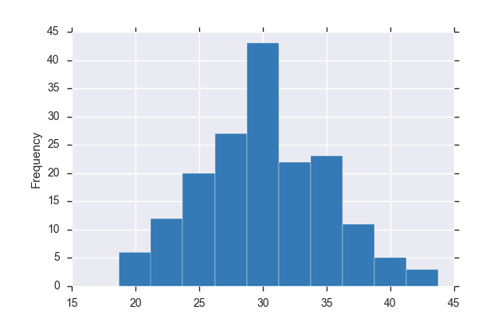

**Common Values**

| Value | Count | Frequency (%) |  |
| --- | --- | --- | --- |
| 29.2125745079 | 1 | 0.3% |  |
| 37.559214628 | 1 | 0.3% |  |
| 39.5464359442 | 1 | 0.3% |  |
| 34.1798524914 | 1 | 0.3% |  |
| 35.8901775073 | 1 | 0.3% |  |
| 26.4990299277 | 1 | 0.3% |  |
| 38.0912540157 | 1 | 0.3% |  |
| 30.622950004 | 1 | 0.3% |  |
| 28.1665079741 | 1 | 0.3% |  |
| 29.6022027035 | 1 | 0.3% |  |
| Other values (162) | 162 | 54.0% |  |
| (Missing) | 128 | 42.7% |  |

**Extreme Values**

Minimum 5 values

| Value | Count | Frequency (%) |  |
| --- | --- | --- | --- |
| 18.7065185753 | 1 | 0.3% |  |
| 18.8284949175 | 1 | 0.3% |  |
| 19.2032343862 | 1 | 0.3% |  |
| 20.1567354388 | 1 | 0.3% |  |
| 20.6973791721 | 1 | 0.3% |  |

Maximum 5 values

| Value | Count | Frequency (%) |  |
| --- | --- | --- | --- |
| 39.5464359442 | 1 | 0.3% |  |
| 39.6314500181 | 1 | 0.3% |  |
| 41.3607389775 | 1 | 0.3% |  |
| 42.8650628508 | 1 | 0.3% |  |
| 43.7530276599 | 1 | 0.3% |  |

padre  
Categorical

| Distinct count | 3 |
| --- | --- |
| Unique (%) | 1.6% |
| Missing (%) | 36.0% |
| Missing (n) | 108 |

| True | 101 |
| --- | --- |
| False | 91 |
| (Missing) | 108 |

Toggle details

| Value | Count | Frequency (%) |  |
| --- | --- | --- | --- |
| True | 101 | 33.7% |  |
| False | 91 | 30.3% |  |
| (Missing) | 108 | 36.0% |  |

renta  
Numeric

| Distinct count | 180 |
| --- | --- |
| Unique (%) | 100.6% |
| Missing (%) | 40.3% |
| Missing (n) | 121 |
| Infinite (%) | 0.0% |
| Infinite (n) | 0 |

| Mean | 34964 |
| --- | --- |
| Minimum | 29076 |
| Maximum | 39791 |
| Zeros (%) | 0.0% |

Toggle details

**Statistics**

Quantile statistics

| Minimum | 29076 |
| --- | --- |
| 5-th percentile | 32035 |
| Q1 | 33651 |
| Median | 34873 |
| Q3 | 36300 |
| 95-th percentile | 38379 |
| Maximum | 39791 |
| Range | 10715 |
| Interquartile range | 2649.4 |

Descriptive statistics

| Standard deviation | 1922 |
| --- | --- |
| Coef of variation | 0.05497 |
| Kurtosis | -0.056525 |
| Mean | 34964 |
| MAD | 1541 |
| Skewness | 0.00043387 |
| Sum | 6258500 |
| Variance | 3693900 |
| Memory size | 2.4 KiB |

**Histogram**

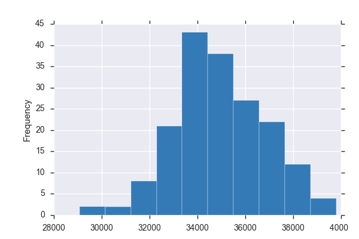

**Common Values**

| Value | Count | Frequency (%) |  |
| --- | --- | --- | --- |
| 34707.5422547 | 1 | 0.3% |  |
| 33899.2449572 | 1 | 0.3% |  |
| 34468.6898181 | 1 | 0.3% |  |
| 34979.614944 | 1 | 0.3% |  |
| 36512.6960642 | 1 | 0.3% |  |
| 33122.6733377 | 1 | 0.3% |  |
| 35480.1151856 | 1 | 0.3% |  |
| 39058.766599 | 1 | 0.3% |  |
| 35982.2452883 | 1 | 0.3% |  |
| 38537.524596 | 1 | 0.3% |  |
| Other values (169) | 169 | 56.3% |  |
| (Missing) | 121 | 40.3% |  |

**Extreme Values**

Minimum 5 values

| Value | Count | Frequency (%) |  |
| --- | --- | --- | --- |
| 29076.1940908 | 1 | 0.3% |  |
| 30118.5408574 | 1 | 0.3% |  |
| 30418.7818007 | 1 | 0.3% |  |
| 30990.1079333 | 1 | 0.3% |  |
| 31595.6411651 | 1 | 0.3% |  |

Maximum 5 values

| Value | Count | Frequency (%) |  |
| --- | --- | --- | --- |
| 38579.9402002 | 1 | 0.3% |  |
| 38722.363654 | 1 | 0.3% |  |
| 39023.5864932 | 1 | 0.3% |  |
| 39058.766599 | 1 | 0.3% |  |
| 39791.2718075 | 1 | 0.3% |  |

tiempo trabajando  
Numeric

| Distinct count | 15 |
| --- | --- |
| Unique (%) | 8.3% |
| Missing (%) | 40.0% |
| Missing (n) | 120 |
| Infinite (%) | 0.0% |
| Infinite (n) | 0 |

| Mean | 4.4556 |
| --- | --- |
| Minimum | -2 |
| Maximum | 12 |
| Zeros (%) | 4.0% |

Toggle details

**Statistics**

Quantile statistics

| Minimum | -2 |
| --- | --- |
| 5-th percentile | 0 |
| Q1 | 2 |
| Median | 4.5 |
| Q3 | 7 |
| 95-th percentile | 9 |
| Maximum | 12 |
| Range | 14 |
| Interquartile range | 5 |

Descriptive statistics

| Standard deviation | 2.7913 |
| --- | --- |
| Coef of variation | 0.62647 |
| Kurtosis | -0.61714 |
| Mean | 4.4556 |
| MAD | 2.3111 |
| Skewness | 0.006486 |
| Sum | 802 |
| Variance | 7.7913 |
| Memory size | 2.4 KiB |

**Histogram**

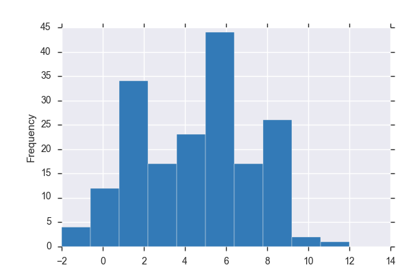

**Common Values**

| Value | Count | Frequency (%) |  |
| --- | --- | --- | --- |
| 5.0 | 25 | 8.3% |  |
| 4.0 | 23 | 7.7% |  |
| 2.0 | 22 | 7.3% |  |
| 6.0 | 19 | 6.3% |  |
| 7.0 | 17 | 5.7% |  |
| 3.0 | 17 | 5.7% |  |
| 8.0 | 15 | 5.0% |  |
| 1.0 | 12 | 4.0% |  |
| 0.0 | 12 | 4.0% |  |
| 9.0 | 11 | 3.7% |  |
| Other values (4) | 7 | 2.3% |  |
| (Missing) | 120 | 40.0% |  |

**Extreme Values**

Minimum 5 values

| Value | Count | Frequency (%) |  |
| --- | --- | --- | --- |
| -2.0 | 2 | 0.7% |  |
| -1.0 | 2 | 0.7% |  |
| 0.0 | 12 | 4.0% |  |
| 1.0 | 12 | 4.0% |  |
| 2.0 | 22 | 7.3% |  |

Maximum 5 values

| Value | Count | Frequency (%) |  |
| --- | --- | --- | --- |
| 7.0 | 17 | 5.7% |  |
| 8.0 | 15 | 5.0% |  |
| 9.0 | 11 | 3.7% |  |
| 10.0 | 2 | 0.7% |  |
| 12.0 | 1 | 0.3% |  |

Sample

|  | edad | padre | renta | tiempo trabajando |
| --- | --- | --- | --- | --- |
| 0 | 24.207792 | False | NaN | 8.0 |
| 1 | 27.083798 | NaN | NaN | 1.0 |
| 2 | NaN | True | NaN | 7.0 |
| 3 | 35.376690 | True | NaN | 4.0 |
| 4 | 23.971585 | NaN | NaN | NaN |

```python
import pandas_profiling

# Tan sencillo como llamar al método ProfileReport(mi_df):
pandas_profiling.ProfileReport(df_padre_con_nan)
```

No está mal, ¿no? A mí me gusta. De hecho, desarrollo una [versión homóloga de `pandas_profiling`, pero para DataFrames de Spark en vez de pandas](https://github.com/julioasotodv/spark-df-profiling).

### 2.D. Otras bibliotecas de visualización

Cada vez aparecen más y más bibliotecas de visualización en Python. La mayoría de las nuevas están parcial o totalmente orientadas a la visualización web. Basta con [buscar en Internet](http://lmgtfy.com/?q=Python+visualization) para encontrar, literalmente, más opciones de las que un ser humano equilibrado puede llegar a utilizar a lo largo de su vida.

- [Lightning](http://lightning-viz.org/): De momento es muy joven, pero apunta a ser de las mejores para visualizaciones en tiempo real de forma sencilla; y compatibles con muchos lenguajes.
- [Pygal](http://www.pygal.org/en/latest/): Escasa en funcionalidad, pero es probablemente la más bonita de cuantas he visto. Incluye gráficos muy curiosos.
- [Plotly](https://plot.ly/): Es bonita y sencilla, y bastante famosa. Ofrece herramientas para gente que no sabe programar; pero también ofrece una [API de Python](https://plot.ly/python/user-guide/) para los que sí saben (¡como tú!). Puedes comenzar leyendo sobre Plotly [aquí](https://plot.ly/python/getting-started/)
- [Bqplot](https://github.com/bloomberg/bqplot): Desarrollada por Bloomberg, es muy reciente (salió hace tres meses aproximadamente). Permite generar visualizaciones interactivas en los Notebooks, al igual que Bokeh y mpld3. A día de hoy está principalmente enfocada a la generación de gráficos de series temporales. Se espera que consiga mucha mayor funcionalidad en el futuro.

## 3. Bibliografía y recursos adicionales

Aparte de todos los links mostrados a lo largo del contenido, recomiendo mirar los siguientes recursos:

- [Python for Data Analysis](http://shop.oreilly.com/product/0636920023784.do): El capítulo 8 muestra cómo utilizar Matplotlib, Numpy y pandas para hacer visualizaciones. La mayoría lo hemos cubierto ya. Recomiendo mirar la parte de visualizaciones de mapas. Asimismo, Bokeh está comenzando a incluir una [API de mapas](http://bokeh.pydata.org/en/0.11.1/docs/user_guide/geo.html) bastante interesante.
- [Interactive Visualization for the Web](http://shop.oreilly.com/product/0636920026938.do): Una introducción amigable a Javascript y D3.js desde 0.

Cabe mencionar que a día de hoy, gran parte de la visualización generada en las empresas proviene de herramientas de Business Intelligence. Aparte de las más famosas (como Tableau, QlikView, Tibco Spotfire, MicroStrategy, SAP Lumira...) recomiendo mirar [Zoomdata](http://www.zoomdata.com/) (la mejor para big data y tiempo real, escrita en D3.js) de entre las de pago; y [Caravel](https://github.com/airbnb/caravel), desarrollada por Airbnb. Ha sido liberada recientemente, así que es 100% libre y gratuita (¡y escrita en Python!).

Profesor: [Julio Antonio Soto](https://twitter.com/julio_a_soto)